# EM-JSMJ210036 364..378

Converted from PDF `Kuppelwieser-CustomerExperienceValueWOM-2022-JSM.pdf` · 15 pages · anchors: page `#pN`, block `#pN-bK`

Page 1

## The role of customer experience in the perceived value–word-of-mouth relationship

#### Volker G. Kuppelwieser Marketing Department, NEOMA Business School, Mont-Saint-Aignan, France

#### Philipp Klaus Department of Marketing, International University of Monaco, INSEEC U. Research Center, Monaco, Europe

#### Aikaterini Manthiou Marketing Department, NEOMA Business School, Mont-Saint-Aignan, France, and

Linda D. Hollebeek Montpellier Business School – University of Montpellier, Montpellier Research in Management, Montpellier, France and Tallinn

University of Technology, Tallinn, Estonia

Abstract Purpose – The customer experience (CX), as revealed in the literature-based debate, has been variously viewed as either a driver or an outcome of customer-perceived value (CPV). However, the association of CPV, CX and word-of-mouth (WoM) behavior remains nebulous to date, thereby generating an important research gap. In response and to bridge this gap, this study aims to explore CX’s role in the CPV–WoM behavior relationship, the role of WoM behavior arising from CX and whether CX acts as a core mediator (vs a moderator) in the association of CPV and subsequent consumer-behavior outcomes. Design/methodology/approach – By conducting two studies spanning a broad range of services, this paper explores the relationship between CPV, CX, and WoM behavior through structural equation modeling. Findings – The findings are that CX plays a crucial role in the CPV–WoM relationship, thereby confirming the existence of a direct link between CPV (social/hedonic/utilitarian value), CX and WoM. The results also highlight CX’s mediating role in the relationship between social and utilitarian (but not hedonic) values. Moreover, the results reveal that the EXQ scale, measuring CX, comprises distinct experiences perceived by high and low CXbased customer segments, respectively. Practical implications – CPV (utilitarian, hedonic, social) not only affects consumers’ behavioral intentions but also, more importantly, their WoM behavior. Therefore, managers need to consider all three values. Moreover, managers should shift their focus from social value perceptions to CX. The results suggest that managers need to devote additional resources to the development of a suitable CX, which will help mitigate consumers’ online and/ or offline brand-related WoM. This study indicates the context in which managers must emphasize the construct that produces positive outcomes. Originality/value – By identifying a direct relationship between CPV, CX and the ensuing consumer-behavior outcomes, the study offers important theoretical insight into CX’s nomological network.

Keywords Consumer-perceived value (CPV), Customer experience (CX), Word-of-mouth (WoM) behavior, Mediator, Moderator, Utilitarian/hedonic/social value, Structural equation modeling

Paper type Research paper

#### 1. Introduction

Understanding the nature and dynamics of customer-perceived value (CPV) has long been regarded as a crucial component of designing and executing successful marketing strategies (Ulaga and Eggert, 2006). Consequently, the exploration of CPV and its marketing outcomes has been identified as a theoretical and practical priority (Kumar and Reinartz, 2016; Figueiredo and Scaraboto, 2016). Various scholars have emphasized CPV’s importance for service marketing research

(Kelleher et al., 2019; Vargo and Lusch, 2017; Zeithaml et al., 2020). In this respect, Grönroos and Voima (2013) maintain that CPV, which is widely defined as a trade-off between benefits (i.e. get) and sacrifices (i.e. give; Zeithaml, 1988), is crucial for “establishing the service perspective on marketing.”

Journal of Services Marketing 36/3 (2022) 364–378 © Emerald Publishing Limited [ISSN 0887-6045] [DOI 10.1108/JSM-11-2020-0447]

Received 9 November 2020 Revised 15 March 2021 20 April 2021 Accepted 28 April 2021

364

Page 2

Previous research mainly focused on estimating CPV’s nomological network-based associations, including customer satisfaction (Ryu et al., 2012), behavioral intentions and loyalty (Floh et al., 2014). However, only a few studies have linked CPV to specific consumer-behavior outcomes, including purchase or word-of-mouth (WoM) (Chang and Wang, 2011). Among others, researchers emphasized WoM as a key CPV outcome (Babic Rosario et al., 2016) because, in addition to exposing a consumer’s focal WoM-disseminating behavior, CPV also influences other behavioral outcomes (Cheung and Thadani, 2012), all of, which, in turn, affect firm performance (Ye et al., 2011). Likewise, Leroi-Werelds (2019) highlights that CPV, “besides its crucial role in decision-making, plays a key role in the post-purchase phase, as customers evaluate the value of the product or service, which determines their satisfaction, repurchase intentions and WoM.” The author implies that a service encounter’s ultimate outcome should be to create value-in-context, which is conducive to the development of a favorable customer experience (CX).

However, CPV’s link to CX remains tenuous (Komulainen et al., 2018; Andrews et al., 2012). Given the experiential, contextual, idiosyncratic and meaning-laden nature of value (Lusch and Vargo, 2014; Vargo and Lusch, 2008), it comes as no surprise that some scholars assume that CX affects the link between CPV and consumer behavior (Lin et al., 2014; De Keyser et al., 2020). Helkkula (2011) notes that CX is strongly linked to hedonic consumption, powerful emotions and enjoyment-derived value. Certain authors, including (Patrício et al., 2011; Candi et al., 2013), conceptualize CX more broadly to include multiple value perceptions that encapsulate emotionally engaging sensations (hedonic benefits), functional utility (utilitarian benefits) and social benefits (Chitturi et al., 2008). However, studies investigating CX’s nature and dynamics, through which it influences CPV and subsequent consumer behavior (e.g. WoM), remain few and far between (Klaus, 2014; Varshneya and Das, 2017).

Based on these gaps, we explore the relationship between CPV, CX and consumers’ behavioral intent/behavior. This research endeavor leads to the following study objectives:

To explore the direct effect of value on WoM and the effect of values on CX and WoM.

To investigate the proposed mediating role of CX in the value–WoM relationship.

To determine the moderating role of CX in the value– WoM relationship.

Our contributions are threefold. First, we analyze how different CPV dimensions (i.e. utilitarian, hedonic and social) affect consumers’ WoM behavior, defined as consumers’ dissemination of positive or negative product/service experiences (Anderson, 1998). Although several authors have assessed the CPV–WoM relationship (Kumar et al., 2007; Gruen et al., 2006), their inconsistent results generate the need to further test and validate the nature of this theoretical association. Throughout this study, we, therefore, aim to substantiate and solidify insights into this association by addressing prior, inconclusive results.

Second and relatedly, we explore CPV’s effect on CX and its subsequent impact on WoM behavior (Klaus, 2014). That is, in addition to the proposed direct relationship between CPV and WoM behavior, we explore the potential mediating effect of CX in this association. The addition of CX as a mediator is based on the following rationale. Although CPV may reflect a customer’s perceived value regarding a particular brand or firm interaction, the individual’s broader product/service experience throughout the purchase journey (i.e. CX; Lemon and Verhoef, 2016) may fully align with CPV generated by focal interactions. Consequently, it is of interest to explore the extent to which CPV affects CX (Nasution and Mavondo, 2008), as done in this study. In turn, as we expect CX to affect customers’ WoM behavior (Cetin and Dincer, 2014; Zhang et al., 2014), we also test this relationship in our study.

Third, in addition to the aforesaid mediating role of CX, we explore CX’s potential moderating role in the association of CPV and WoM behavior. That is, whereas the aforesaid mediating effect intuitively makes sense, it could be argued that a customer’s experience level acts as an important determinant of the strength of the association between CPV and WoM behavior, as expressed in a moderating relationship (De Keyser et al., 2015). In this respect, an elevated (weak) CX would strengthen (lower) the CPV–WoM behavior nexus, which also makes sense. Overall, our main contribution stems from empirically testing and validating the CPV–CX–WoM behavior-based nomological network by unraveling the nature of the relationship between the respective constructs, thereby adding more conclusive evidence results to the way in which these concepts are addressed.

#### 2. Theoretical foundations

In this section, we review important CPV literature and discuss the association of CPV with CX and WoM. First, we follow Holbrook’s (1994) and Rintamäki et al.’s (2006) multidimensional view of CPV based on the utilitarian (Babin et al., 1994), hedonic (Berlyne, 1970) and social value dimensions (Sweeney and Soutar, 2001; Sheth, 1981; Westbrook and Black, 1985). For the purposes of this research, we use Sweeney and Soutar’s (2001) PERVAL model as a theoretical foundation to develop utilitarian, hedonic and social values. Utilitarian value refers to “the utility derived from the (product’s) perceived quality and expected performance” (Sweeney and Soutar, 2001). This value is mainly functional, task-related and rational by nature (e.g. fair pricing, convenience; Babin et al., 1994). Hedonic value is “the utility derived from the feelings or affective states that a product generates” (Sweeney and Soutar, 2001). This emotional value is exemplified by consumer pleasure, fun and entertainment (Berlyne, 1970; Holbrook and Hirschman, 1982). Social value refers to “the utility derived from the product’s ability to enhance social self-concept” (Sweeney and Soutar, 2001). It

Role of customer experience

Volker G. Kuppelwieser et al.

Journal of Services Marketing

Volume 36 · Number 3 · 2022 · 364–378

365

Page 3

includes the value derived from the product’s social status and social self-esteem (Rintamäki et al., 2006; Vigneron and Johnson, 1999).

Second, most definitions highlight CPV’s customer-perceived nature, which is based on a customer’s personal, subjective evaluations of an offering, thus revealing CX’s key link to CPV (Berry et al., 2002). Furthermore, although they recognize this close link, firms often struggle to deal with CX-related complexity and management (De Keyser et al., 2015). Similarly, empirical insight into the CPV–CX interface remains tenuous, particularly in respect of the two elements’ ensuing behavioral outcomes (Klaus, 2014; Lemon and Verhoef, 2016) explored by this paper. Existing research proffers various views of the CPV–CX interface (Klaus, 2014). Patrício et al. (2011) and, for example, assess the CPV–CX relationship from a customer-journey perspective (cf. Helkkula and Kelleher, 2010), Wan et al. (2017). However, despite this insight, a dearth of research explores the dynamics through which CX influences the link between CPV and focal consumer-behavior outcomes. Based on this gap, we investigate CX’s effect on the relationship between CPV and consumers’ ensuing behavioral outcomes (Keiningham et al., 2020) as measured by WoM behavior (Brown et al., 2005).

Third, given CX’s context-specific nature (Lemke et al., 2011), it is important to explore the CPV–CX–WoM relationship in different settings. We, therefore, advocate assessing all three clusters of Silvestro et al.’s (1992) service classification scheme to identify potentially differing crosscontextual dynamics (Klaus and Maklan, 2013). For our empirical research, we specifically chose a high-end professional service, a mass (grocery) service and a utilitarian service (retail banking). Given CX’s inclination to differ contextually (Lemke et al., 2011), it can either mediate or moderate the CPV–WoM link, depending on the specific CPV dimension (i.e. social, hedonic or utilitarian; see (Jamshidi et al., 2017; Walls, 2013). Our key literature-based findings are summarized in Table 1.

Fourth, having previously introduced the notions of utilitarian, hedonic and social value, we subsequently delve further into their respective links with CX and ensuing consumer behaviors. Utilitarian and hedonic values have been found to be closely linked to online and offline CX (Lin and Kuo, 2016). For example, Wan et al. (2017) investigated utilitarian value’s effect on CX in an online, personalized service setting (Viswanathan et al., 2017), while Tynan et al. (2014) and Lin and Kuo (2016) confirmed its effect on CX in the more hedonic luxury automobile and tourism contexts, respectively (Table 2).

Although social value’s link to CX has received less attention, it is presumed to exert a positive effect on CX (Kang and Lee, 2018). Given the proposed effect of social media on CX (Hollebeek et al., 2014; Klaus, 2013), scholars have mainly explored the social value–CX relationship in online settings (Srivastava and Kaul, 2014). Kang and Lee (2018), for example, drew on experiments to investigate the impact of social presence/value on e-service-based CX. Moreover, Chen and Lin (2015) and Zhang et al. (2014) established how social value perceptions affect virtual CX on social networks and blogs (Table 3). Based on our literature review, we develop a conceptual framework (Figure 1) that outlines our proposed

rival approaches to the three-way CPV–CX–WoM interface, as discussed in the next section.

#### 3. Method

We designed two quantitative studies to shed light on CX’s role in the CPV–WoM relationship. Study 1 uses a series of exploratory factor analyses (EFAs), focusing on an exploration of the factor structures of our conceptual model’s constructs. Study 2 validates the scales in subsequent confirmatory factor analysis (CFA) and applies them in a structural equation model. When altering the model’s depicted relationships, we gained insights into CX’s role in the CPV–consumer-behavior outcome relationship.

3.1 Study 1 – measurement and scales We first collected 150 customers’ data covering each of Silvestro et al.’s (1992) major service types (Dagger et al., 2007). The UK-based market research agency collected the responses of the UK customers from their existing panel. To qualify for survey participation, respondents had to confirm that they have had an experience with the service provider in question during the six weeks prior to receiving the survey. Responses were obtained through an online platform. As previously mentioned, the data set originated from a professional service (n = 57), the respondents’ main bank (n = 47) and their main grocery retailer (n = 46). Table 4 provides an overview of the data set’s descriptive statistics.

We adapted the scale items from established measures and adjusted them to the particular research context of this study. Utilitarian value was gauged by adapting relevant items from the scales of Sweeney and Soutar (2001), Jones et al. (2006) and Anderson and Srinivasan (2003). Hedonic value was measured by using the scales of Sweeney and Soutar (2001), Soutar and Sweeney (2003) and Jones et al. (2006). Social value was assessed by using Sweeney and Soutar’s (2001) and Rintamäki et al.’s (2006) items. We used Brown et al.’s (2005) established seven-item scale, which has been widely adopted (Sweeney et al., 2012) and used to measure WoM in CX research (Klaus and Maklan, 2013). The appendix provides an overview of the items used. To measure CX, we followed the guidance offered by e.g. Lemon and Verhoef (2016) and used a multidimensional scale encompassing multiple touchpoints. We applied Klaus’s (2012, 2013) EXQ scale, validated by subsequent research (Roy, 2018; Deshwal, 2016). Lemon and Verhoef (2016) recommend Klaus’s EXQ scale as a more advanced CE measure than, for example, the more “exploratory measures” (p. 69) offered, among others, by Brakus et al.’s (2009) brand experience scale. Prior to our study, several researchers have drawn on the EXQ scale and its underlying theoretical considerations (Chang and Chiu, 2016).

Role of customer experience

Volker G. Kuppelwieser et al.

Journal of Services Marketing

Volume 36 · Number 3 · 2022 · 364–378

366

Page 4

[output not shown]

NOTE: table converted from PDF layout to HTML text; cell boundaries are reconstructed. See PDF if exact alignment matters.

Table 1 Prior research: hedonic value/CX relationship

Role of customer experience

Volker G. Kuppelwieser et al.

Journal of Services Marketing

Volume 36 · Number 3 · 2022 · 364–378

367

Page 5

With the exception of one item on the hedonic value scale (0.615), the remaining value and WoM scales showed

acceptable results, with item loadings above 0.8. Owing to the other items’ high loadings, we retained them in our subsequent analyses. The appendix provides an overview of the adopted items and their loadings on the remaining scales.

3.2 Study 2 – identifying the role of customer experience In Study 2, we collected a new data set of 322 customers who followed the same service dispersion as in Study 1: namely, 95 respondents assessed a recent professional service experience, 105 an experience with their main bank and 122 their recent grocery

Table 2 Prior research: utilitarian value/CX relationship

| Reference | Sample | Methodologicalapproach | Mainresults |
| --- | --- | --- | --- |
| Martin-Ruiz et al . | 80hotelsand2400customers , | Quantitativeapproach | Serviceexperiencehasapositiveinfluenceonutilitarian |
| (2012) |  |  | value(servicequality serviceconvenience serviceequity , , |
|  |  |  | andpricefairness) |
| El -Adly and Eid (2016) | 382mallshoppers | Quantitativeapproach | CPVatamallcomprisessevendimensions namely , , |
|  |  | Structuralequationmodeling | hedonic utilitarian self -gratification epistemic social , , , , |
|  |  |  | interaction transactionandtimeconvenience whichwill , , |
|  |  |  | impactcustomers’experiencesatthemall |
| DubeandHelkkula | Sevendiarynarrativeson | An empirical two-phase study | Aserviceexperiencehasfunctionaloutcomes |
| (2015) | usingaspecificappand23 |  |  |
|  | semi -structured interviews on |  |  |
|  | theuseofapps |  |  |
| Chiuetal (2014) . | 782Yahoo!Kimocustomers | Quantitativeapproach | Inonlinestores utilitarianvalueandhedonicvalueare , |
|  |  |  | importantforexperiencedbuyers |
| Wanetal (2017) . | 990participants | In-depth interviews and | Functionalvaluehasanimpactontheonline |
|  |  | experimentalresearch | customizationexperience |
| Walls(2013) | 451Orlandovisitorsina | Quantitativeapproach | Theexperiencederivedfromaphysicalenvironmentand |
|  | hospitalitysetting |  | humaninteractionhasaninfluenceonitscognitivevalue |
| Tynanetal (2014) . | Eightparticipants | Aqualitativeapproachwith | Functional/utilitarianvaluederivedfromthe |
|  |  | in-depth interviews | consumptionofaluxurycarexperience |
| ChenandLin(2015) | 216B&BlodgersinTaiwan | Quantitativeapproach | CXhasanimpactonutilitarianvalue |
| LinandKuo(2016) | 639touristswhohadvisitedat | Quantitativeapproach | Perceived utilitarian value (money paid and give-get |
|  | leastoneofthe17Taiwanese |  | tradeoffimpactstouristexperience) |
|  | townshipswithintheprevious |  |  |
|  | 12months |  |  |
| Holbrook(2006) | Writtenmemoirswereusedas | Aqualitativeapproachwitha | ThreeFs(fantasies feelingsandfun)contributeto , |
|  | apathtoinsightsintothe | photographicessay | economiccustomervalue |
|  | customervalue’sroleinthe |  |  |
|  | consumptionexperience |  |  |
| Gentileetal (2007) . | 2368surveysof12different , | Quantitativeapproach | Experienceimpactsconsumerutilitarianvalue |
|  | products |  |  |
| Jamshidietal (2017) . | 1032bankcustomers , | Quantitativetechnique | Mobilebanking’sutilitarianfeaturesaffecttheflow |
|  |  |  | experience |
| Flohetal (2017) . | Anonlineexperimentwith | Aquantitativestudy | Valueperceptionsinthemobilecommunicationssetting |
|  | 1392participants , | Aseriesofqualitative | aregeneratedthroughthedimensionsofthe |
|  |  | interviewsandfocusgroups | functionality economicaspects emotions andsocial , , , |
|  |  | withcustomersofalarge | facetsofboththeserviceandtheproduct |
|  |  | Europeantelecommunications |  |
|  |  | company |  |
| Prebensenand | Fourdifferentservice | Experimentaldesign | Utilitarianvaluedimensionsarepresentinfourdifferent |
| Rosengren(2016) | experiences withatotalof , |  | serviceexperiences |
|  | 938membersofanationally |  |  |
|  | representativeonlinepanelin |  |  |
|  | Sweden |  |  |
| ChenandLin(2015) | 452validquestionnaires | Quantitativeapproach | CXinfluencesblogs’actualperformance |

NOTE: table converted from PDF layout to HTML text; cell boundaries are reconstructed. See PDF if exact alignment matters.

Role of customer experience

Volker G. Kuppelwieser et al.

Journal of Services Marketing

Volume 36 · Number 3 · 2022 · 364–378

368

Page 6

shopping experience. The UK-based market research agency collected the responses of the UK customers from their existing panel. To qualify for survey participation, the respondents had to confirm an experience with the service provider in question during the past six weeks prior to receiving the survey. Responses were obtained through an online platform. Table 4 provides an overview of the data set’s descriptive statistics. In this regard, we applied the same scales as used in Study 1.

Study 2 examined CX’s differing effects on consumerperceived utilitarian, hedonic and social value (Rintamäki et al., 2006), which tend to be interrelated (Hsiao et al., 2016). As a CFA would lead to a non-discriminant solution, we, therefore, separately focused on CX’s different effects on each value concept, as a model that combines these value types into a single CPV would limit the insights we need to address the previously identified research gaps[1].

Table 3 Prior research: social value/CX relationship

| Reference | Sample | Methodologicalapproach | Mainresults |
| --- | --- | --- | --- |
| Prebensenand | 395touristsvisitingoneoffour | Quantitativeapproachwith | Adventure tourists’ mastering and psychological co-creation lead |
| Xie(2017) | companiesofferingwinter | logisticregression | tosocialvalue |
|  | experiencesinnorthernNorway |  |  |
| Shamimetal . | 711respondentsfromfour | Quantitativeapproach | Brandexperiencehasapositiveinfluenceonthecustomervalue |
| (2016) | hypermarketslocatedinfive |  | co-creation attitude (interaction attitude knowledge sharing , , |
|  | Malaysianstates |  | responsive attitude) and the customer value co-creation behavior |
|  |  |  | (participationbehavior citizenshipbehavior) , |
| Seraj(2012) | 11activemembersofthe | Netnography | Thesocialvalue forexample theplatforminteractivitythrough , , |
|  | community | Online and offline in-depth | socialties isanimportantcharacteristicofperceivedonline , |
|  |  | interviews | communityvalue |
| Holbrook | Writtenmemoirswereusedasa | Aqualitativeapproachwitha | ThreeFs(fantasies feelings fun)contributetoaltruisticcustomer , , |
| (2006) | pathtoinsightsintocustomer | photographicessay | value |
|  | value’sroleintheconsumption |  |  |
|  | experience |  |  |
| Srivastavaand | 840departmentstoreshoppers | Quantitativeapproach | SocialinteractionhasapositiveanddirecteffectonCX |
| Kaul(2016) |  |  |  |
| El -Adly and Eid | 382mallshoppers | Quantitativeapproach | CPVatamallcomprisessevendimensions namely hedonic , , , |
| (2016) |  | Structuralequationmodeling | utilitarian self -gratification epistemic social interaction , , , , |
|  |  |  | transactionandtimeconvenience whichwillimpactcustomers’ , |
|  |  |  | experiencesatthemall |
| Flohetal . | Anonlineexperimentwith1392 , | Aquantitativestudy | Valueperceptionsinamobilecommunicationssettingare |
| (2017) | participants | Aseriesofqualitative | generatedthroughthedimensionsofthefunctionality economic , |
|  |  | interviewsandfocusgroups | aspects emotionsandsocialfacetsofbothaserviceanda , |
|  |  | withcustomersofalarge | product |
|  |  | Europeantelecommunications |  |
|  |  | company |  |
| Zhangetal . | 563onlinequestionnairesfrom | Quantitativeapproach | Perceivedinteractivityandsociabilityhaveanimpactonvirtual |
| (2014) | Renren(asocialnetworking |  | CX |
|  | service)usersand446from |  |  |
|  | SinaWeibo (a micro-blogging |  |  |
|  | service)users . |  |  |
| ChenandLin | 452validquestionnaires | Quantitativeapproach | CXinfluencesthedegreetowhichblogslinktheiruserstothe |
| (2015) |  |  | othermembersofthecommunity |
| KangandLee | Responsestoahypothetical | Experimentalstudy | Socialpresencehasamajorinfluenceoncustomers’affective |
| (2018) | newsportal |  | experienceofeservices |
| Jutbring(2018) | AWebsurveywith1757 , | Quantitativeandqualitative | Theperceivedconsumervalueistheindividualoutcomeofa |
|  | responses | methods | socialmarketingexchange |
|  | Five in-depth interviews with |  |  |
|  | festivalvisitors |  |  |

NOTE: table converted from PDF layout to HTML text; cell boundaries are reconstructed. See PDF if exact alignment matters.

Role of customer experience

Volker G. Kuppelwieser et al.

Journal of Services Marketing

Volume 36 · Number 3 · 2022 · 364–378

369

Page 7

3.2.1 Step 1 – direct relationship To identify CX’s role in the CPV–WoM relationship, we tested the direct relationship between our three value-based constructs (i.e. utilitarian, hedonic and social) and WoM. Each of the value constructs demonstrated a significant (p < 0.001) impact on WoM [0.692; 0.742] (Table 6). We next included CX as a direct relationship in the link between CPV and WoM. Again, our results

showed a significant (p < 0.001) effect in the link emerging from each of the focal value types to CX [0.635; 0.849] and from CX to WoM [0.642; 0.647].

3.2.2 Step 2 – mediating effects In this step, we tested for CX’s mediating effects on the CPV– WoM relationship. In line with our previous calculations, we

Figure 1 Conceptual overview

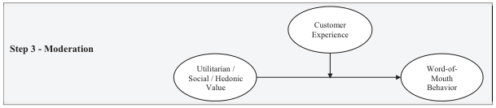

NOTE: figure/graphic rendered as an image from the PDF; its content is not machine-readable text. Caption (if any) follows as the next block.

**text found inside the figure**

**Step 3 - Moderation**

Utilitarian / Social / Hedonic

Value

Word-of-

Mouth Behavior

Customer Experience

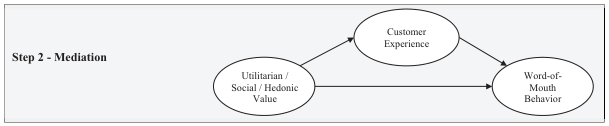

NOTE: figure/graphic rendered as an image from the PDF; its content is not machine-readable text. Caption (if any) follows as the next block.

**text found inside the figure**

**Step 2 - Mediation**

Utilitarian / Social / Hedonic

Value

Word-of-

Mouth Behavior

Customer Experience

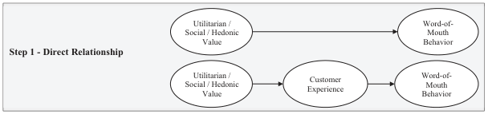

NOTE: figure/graphic rendered as an image from the PDF; its content is not machine-readable text. Caption (if any) follows as the next block.

**text found inside the figure**

**Step 1 - Direct Relationship**

Utilitarian / Social / Hedonic

Value

Word-of-

Mouth Behavior

Utilitarian / Social / Hedonic

Value

Word-of-

Mouth Behavior

Customer Experience

Table 4 Demographic information

| Demographics | Frequency | Study1a | (%) | Frequency | Study2b | (%) |
| --- | --- | --- | --- | --- | --- | --- |
| Gender |  |  |  |  |  |  |
| Man | 90 |  | 60 | 143 |  | 444 . |
| Woman | 60 |  | 40 | 179 |  | 556 . |
| Agecluster |  |  |  |  |  |  |
| 18 24 – | 13 |  | 87 . | 28 |  | 87 . |
| 25 34 – | 24 |  | 160 . | 76 |  | 236 . |
| 35 44 – | 31 |  | 207 . | 58 |  | 180 . |
| 45 54 – | 23 |  | 153 . | 63 |  | 196 . |
| 55 64 – | 44 |  | 293 . | 56 |  | 174 . |
| 651 | 15 |  | 100 . | 41 |  | 127 . |
| Income |  |  |  |  |  |  |
| Under£9499 , | 10 |  | 67 . | 26 |  | 81 . |
| £9500 £15499 , – , | 27 |  | 180 . | 32 |  | 99 . |
| £15500 £24999 , – , | 18 |  | 120 . | 59 |  | 183 . |
| £25000 £49999 , – , | 56 |  | 373 . | 119 |  | 370 . |
| £50000 £74999 , – , | 17 |  | 113 . | 37 |  | 115 . |
| £75000orover , | 12 |  | 80 . | 20 |  | 62 . |
| Donotknow | 2 |  | 13 . | 7 |  | 22 . |
| Wouldrathernotsay | 8 |  | 53 . | 22 |  | 68 . |
| Notes: an=150; b n=322 |  |  |  |  |  |  |

NOTE: table converted from PDF layout to HTML text; cell boundaries are reconstructed. See PDF if exact alignment matters.

Role of customer experience

Volker G. Kuppelwieser et al.

Journal of Services Marketing

Volume 36 · Number 3 · 2022 · 364–378

370

Page 8

included CX as a mediator in the three models. Estimating these models revealed that the paths from each of our three value types to WoM remained significant (p < 0.001): [0.484; 0.716]. Although the path coefficients from each of our value types to CX were also significant (p < 0.001): [0.624; 0.843], the coefficients from CX to WoM differed across the three value types. Social value’s path coefficient was impactful and significant (0.333, p < 0.001). However, in respect of the utilitarian value, CX had a lower and only marginally significant (p < 0.1) effect on WoM (0.169). Conversely, hedonic value resulted in a non-significant and undirected path coefficient (0.029, p> 0.1). Consequently, these results indicate that CX partially mediates the social value– WoM relationship (D = 0.208, p < 0.05) and the utilitarian value–WoM relationship (D = 0.143, p < 0.05), but that it does not mediate the hedonic value–WoM relationship. Table 6 provides an overview of our main results.

3.2.3 Step 3 – moderating influence Our final step focused on examining CX’s potentially moderating effect on the path from CPV to WoM. This test required partitioning the data set into relevant subsets with high vs low CX

regarding particular services. A multi-group assessment of individuals with high CX (vs low CX) facilitated the assessment of measurement invariance. As shown in step 1, the three (unconstrained) CFA models’ goodness-of-fit measures were satisfactory (Hair et al., 2010). The scales thus showed the factor structure equivalence between the two groups. The full metric invariance assessment also yielded a satisfactory goodness-of-fit for the sample (Min x <sup>2</sup>/df = 3.762, Min CFI = 0.870, Max RMSEA = 0.093). The final nested model, which tested for x <sup>2</sup> differences between the two groups, was significant (p = [0.018; 0.036]), thereby demonstrating the metric variance of both the high and low CX models. Nevertheless, our results failed to support CX’s moderating influence on the CPV–WoM relationship (Table 6).

Table 5 Items and loadings

|  | Study1a |  |  | Study2b |  |
| --- | --- | --- | --- | --- | --- |
|  | Initial | Purified | Hedonic | Utilitarian | Social |
| Item | EFA | EFA | model | model | model |
| Brandexperience |  |  |  |  |  |
| Thecompanyhasagoodreputation | 0699 . | 0707 . | 0761 . | 0762 . | 0763 . |
| Ihaveconfidenceinthecompany’sexpertise | 0847 . | 0863 . | 0808 . | 0810 . | 0809 . |
| Thecompanygivesindependentadvice(onwhichproduct/servicewillbestsuitmy |  |  |  |  |  |
| needs) | 0725 . | 0713 . | 0728 . | 0729 . | 0734 . |
| Ichoosethecompany butnotjustbecauseoftheprice , | 0418 . | – | – | – | – |
| Thepeoplewhoworkatthecompanyrepresentthecompanybrandwell | 0826 . | 0832 . | 0800 . | 0799 . | 0797 . |
| Thecompany’sofferingshavethebestquality | 0867 . | 0863 . | 0817 . | 0818 . | 0821 . |
| Thecompany’sofferingsaresuperior | 0850 . | 0845 . | 0821 . | 0822 . | 0826 . |
| Serviceproviderexperience |  |  |  |  |  |
| Thecompanyadvisedmethroughouttheprocess | 0800 . | 0771 . | 0741 . | 0742 . | 0744 . |
| Dealingwithcompanyiseasy | 0825 . | 0838 . | 0790 . | 0789 . | 0784 . |
| Thecompanykeepsmeinformed | 0860 . | 0867 . | 0747 . | 0746 . | 0746 . |
| Thecompanydemonstratesflexibilityindealingwithme | 0869 . | 0876 . | 0780 . | 0780 . | 0784 . |
| AtthecompanyIalwaysdealwiththesameformsand/orsamepeople | 0615 . | – | – | – | – |
| Thecompany’spersonnelrelatetomywishesandconcerns | 0817 . | 0805 . | 0831 . | 0830 . | 0831 . |
| ThepeopleIdealwith(atcompany)havegoodpeopleskills | 0882 . | 0891 . | 0843 . | 0843 . | 0842 . |
| Thecompanyprovidesagoodcustomerservice | 0896 . | 0909 . | 0832 . | 0831 . | 0823 . |
| Ihavebuiltapersonalrelationshipwiththepeopleatcompany | 0747 . | 0718 . | 0710 . | 0708 . | 0714 . |
| Thecompany’sfacilitiesarebetterdesignedtofulfillmyneedsthanthoseoftheir |  |  |  |  |  |
| competitors | 0849 . | 0851 . | 0771 . | 0773 . | 0776 . |
| Thecompany’s(onlineand/oroffline)facilitiesaredesignedtobeasefficientas |  |  |  |  |  |
| possible(forme) | 0707 . | 0719 . | 0626 . | 0627 . | 0627 . |
| Post-purchase experience |  |  |  |  |  |
| Istaywiththecompanybecausetheyknowme | 0679 . | – | – | – | – |
| ThecompanyknowsexactlywhatIwant | 0817 . | 0792 . | 0767 . | 0769 . | 0770 . |
| The company keeps me up-to-date | 0871 . | 0861 . | 0712 . | 0714 . | 0713 . |
| Thecompanywilllookaftermeforalongtime | 0903 . | 0894 . | 0771 . | 0772 . | 0769 . |
| Thecompanydeals(t)wellwithmewhenthingsgo(went)wrong | 0732 . | 0741 . | 0717 . | 0718 . | 0715 . |
| Iamhappywiththecompanyasmycategory | 0808 . | 0822 . | 0728 . | 0729 . | 0719 . |
| Beingacustomerat/customerofthecompanygainsmesocialapproval | 0591 . | – | – | – | – |
| Notes: an=150; b n=322 |  |  |  |  |  |

NOTE: table converted from PDF layout to HTML text; cell boundaries are reconstructed. See PDF if exact alignment matters.

Role of customer experience

Volker G. Kuppelwieser et al.

Journal of Services Marketing

Volume 36 · Number 3 · 2022 · 364–378

371

Page 9

#### 4. Discussion and theoretical and practical implications

In this paper, we set out to address three objectives deemed crucial to advance knowledge of the CPV–consumer-behavior outcomes relationship and of how CX affects this relationship. We subsequently discuss our findings and their key implications for marketing theory and practice in greater depth. First, our finding is that CPV (utilitarian, hedonic and social) not only affects consumers’ behavioral intentions but, more importantly, also their WoM behaviors, thereby adding this insight to the literature. More specifically, in line with Lin et al. (2005), we provide insight into the ways in which CPV affects consumer behavior, thereby extending it beyond the realm of behavioral intentions. By investigating the relationship between utilitarian, hedonic and social CPV and WoM behavior, we not only contribute to our understanding of the way in which CPV drives behavior but also explore how CX affects these associations.

Second, since this – to the best of our knowledge – is the first empirical study to identify a direct relationship between CPV, CX and consumer behavior, it makes a related theoretical contribution. This contribution allows managers, who until now have tended to rely on CPV’s effect on consumers’ behavioral intentions, to take a significant stride forward.

Consequently, our finding that CPV exerts an important effect on the ensuing consumer behavior (i.e. WoM) has important practical implications, as managers may want to allocate additional resources to ensure a suitable customer value experience, which could help mitigate consumers’ online and/ or offline brand-related WoM (Hollebeek et al., 2019). As WoM can be either positive or negative, we advise managers to regard our findings as a key strategic imperative that could enhance their businesses’ performance outcomes. Depending on their brands’ nature, managers might also want to determine which of utilitarian, hedonic or social value is most important in their particular context, and to draw appropriate strategic conclusions from their analyzes (e.g. by focusing – in line with Study 2’s results – more on utilitarian and social value and less on hedonic value).

Third, our finding is that CX has a mediating effect on the CPV–WoM relationship, which indicates that CX reduces this relationship’s strength between customers’ value perceptions and their WoM behavior. However, our finding is also that this mediating effect only applies to social and utilitarian value perceptions. The CX mediating effect is dominant when consumers perceive a social or a utilitarian value, but more specifically the case when they perceive a social value. We found no mediating effect in respect of hedonic value perceptions. These findings imply that – in terms of social value derived from interactions with others – CX can weaken the relationship between social value and WoM behavior. Emphasizing social value leads to less WoM behavior. Consequently, if the managerial emphasis is on increasing positive WoM behavior, managers should shift their focus from social value perceptions to CX. Conversely, reduced negative WoM is expected to benefit the firm, which means that specific WoM communications’ valence should also be taken into account.

How can managers achieve this? They could, for example, give customers an opportunity to reflect on and recall their brand-related experiences by soliciting customer feedback or raising their awareness of specific CX-based touchpoints (e.g. in-store, online) by offering brand-related incentives, free gifts, etc. The same holds for utilitarian value perceptions, which CX also mediates to a significant extent. To our surprise, CX was

Table 6 Results for the three value models

| Model | Socialvalue | Hedonicvalue | Utilitarianvalue |
| --- | --- | --- | --- |
| ValuefiWOM | 0692 . | 0742 . | 0693 . |
| CXdirect ValuefiCX CXfiWOM | 0635 . 0642 . | 0849 . 0647 . | 0846 . 0642 . |
| Mediation ValuefiWOM ValuefiCX | 0484 . 0624 . | 0716 . 0843 . | 0550 . 0841 . |
| CXfiWOM | 0333 . | 0029 . | 0169 . |
| Moderation ValuefiWOM(lowCX) ValuefiWOM(highCX) | 0534 . 0620 . | 0631 . 0571 . | 0530 . 0527 . |
| D | 0086 . | 0060 . | 0003 . |
| Notes: p<0001; p<01 . . |  |  |  |

NOTE: table converted from PDF layout to HTML text; cell boundaries are reconstructed. See PDF if exact alignment matters.

Table 7 Summary of the studies’ results

[output not shown]

NOTE: table converted from PDF layout to HTML text; cell boundaries are reconstructed. See PDF if exact alignment matters.

Role of customer experience

Volker G. Kuppelwieser et al.

Journal of Services Marketing

Volume 36 · Number 3 · 2022 · 364–378

372

Page 10

not found to mediate the link with hedonic value. Based on expert discussions with fellow scholars, we came to the conclusion that – when investigating WoM as a dependent variable – we might have affected the latter result. We therefore specifically suggest that utilitarian value requires the necessary items or needs (jobs to be done) to be fulfilled, to allow the CX of this fulfillment to become the focus, thereby mediating the relationship between utilitarian value perceptions and WoM.

Consequently, if a product or the experience of obtaining a product fails to fulfill consumers’ utilitarian needs, this part of their experience strongly influences their willingness to engage in (negative) WoM behavior, even when they enjoyed the experience in other respects (e.g. high hedonic value). We, therefore, identify a tiering or hierarchy of consumer needs that impact on the nature of their experience, with utilitarian needs (if present) trumping hedonic or social needs, particularly to meet core services (e.g. retail banking) required by or the core needs of the consumers.

Social value arises when, for example, we share our CX with others, by definition offering a strong link to WoM behavior. In addition, consumers tend to focus on hedonic value perceptions more inwardly. Within themselves, their willingness to share their brand-related experiences with others and to engage in WoM behavior (Groeger et al., 2016) may to a lesser extent be due to the nature of the hedonic value. However, these value types may significantly overlap, for example, when consumers enjoy brand-related social interactions (e.g. dance classes).

Our findings imply that managers of hedonic value brands should not only emphasize this hedonic value in brand-related communications but should also emphasize the outcome of customers’ brand-related experiences (e.g. achieving a sense of delight, competence, etc., after using the service) as opposed to focusing on the experience as such (i.e. while using the service). This approach is expected to work well in respect of aspirational brands, especially when consumers strive to achieve particular goals and to better themselves in some way (e.g. education or beauty and the use of physical appearancerelated products, such as weight loss items and haircare products). As such, the nature of these customer outcomes could become utilitarian in their own way (e.g. having shinier hair after using a specific shampoo), thereby offering not only a hedonic but also a utilitarian benefit.

Fourth, we find that CX does not moderate the CPV–WoM behavior relationship. Fundamentally, researchers need invariant models if they intend to test for moderation. However, our methodological process did not support the high and low CX groups’ use of invariant models, which implies that the final models could not be compared (moderated). This surprising result suggests that high and low CX differ more fundamentally than previously assumed, as customers in the high-CX group do more than merely rate their CX higher than that of the customers in the low group. From a methodological perspective, the results suggest that the CX scale should include these two groups’ distinct experiences.

#### 5. Future research directions and limitations

Despite the insights revealed by our findings, we encourage researchers to conduct more research on this topic and research

area to validate our findings and refine our results. Researchers could, for example, use different behavioral outcomes (rather than WoM) and switch behavior to explore the effects of CX on firm-based performance measures, such as share-of-category or share-of-wallet. We also advise scholars to explore these and related dynamics in different research settings, such as online/ offline, tangible goods/services and different industry contexts. Researchers should also examine Silvestro et al.’s (1992) service types or other service typologies to establish their individual differences across service contexts.

As we focus on CX’s generic role in services, this paper does not analyze the different CX dimensions. Further research should therefore examine low and high CX groups in different contexts and identify their underlying evaluation dimensions. For example, it is essential to know – if indeed the case – in what context and why a specific dimension or a combination of the three EXQ dimensions drives consumer behavior more than any other dimension or combination of dimensions. Additionally, we encourage researchers to expand our research by exploring other settings than the setting we investigated. For example, it would be advantageous to investigate whether and, if the case, how a more hedonic setting, such as tourism or a luxury setting, confirms our findings. The same applies if researchers were to explore online settings and/or extend their research scope to omnichannel experiences. We also encourage researchers to investigate if a brand’s nature and orientation in terms of value (social, hedonic and utilitarian or any combination thereof) determine CX perception and what exactly drives their consumer behavior.

#### Note

1 We nevertheless determined this all-inclusive model and found that only hedonic value and utilitarian value were non-discriminant. While hedonic value showed an average variance extracted (AVE) of 0.836, determining the utilitarian value resulted in an AVE of 0.844. The two constructs correlated with r = 0.95, and therefore, violated the Fornell and Larcker (1981) criterion.

#### References

Anderson, E.W. (1998), “Customer satisfaction and word of

mouth”, Journal of Service Research, Vol. 1 No. 1, pp. 5-17. Anderson, R.E. and Srinivasan, S.S. (2003), “E-satisfaction

and e-loyalty: a contingency framework”, Psychology and Marketing, Vol. 20 No. 2, pp. 123-138. Andrews, L., Drennan, J. and Russell-Bennett, R. (2012),

“Linking perceived value of mobile marketing with the experiential consumption of mobile phones”, European Journal of Marketing, Vol. 46 Nos 3/4, pp. 357-386. Babic Rosario, A., Sotgiu, F., De Valck, K. and Bijmolt, T.H.A.

(2016), “The effect of electronic word of mouth on sales: a meta-analytic review of platform, product, and metric factors”, Journal of Marketing Research, Vol. 53 No. 3, pp. 297-318. Babin, B.J., Darden, W.R. and Griffin, M. (1994), “Work and/

or fun: measuring hedonic and utilitarian shopping value”, Journal of Consumer Research, Vol. 20 No. 4, pp. 644-656.

Role of customer experience

Volker G. Kuppelwieser et al.

Journal of Services Marketing

Volume 36 · Number 3 · 2022 · 364–378

373

Page 11

Berlyne, D.E. (1970), “Novelty, complexity, and hedonic value”,

Perception & Psychophysics, Vol. 8 No. 5, pp. 279-286. Berry, L.L., Carbone, L.P. and Haeckel, S.H. (2002),

“Managing the total customer experience”, MIT Sloan Management Review, Vol. 43 No. 3, pp. 85-89. Brakus, J.J., Schmitt, B.H. and Zarantonello, L. (2009), “Brand

experience: what is it? How is it measured? Does it affect loyalty?”, Journal of Marketing, Vol. 73 No. 3, pp. 52-68. Brown, T.J., Barry, T.E., Dacin, P.A. and Gunst, R.F. (2005),

“Spreading the word: investigating antecedents of consumers’ positive word-of-mouth intentions and behaviors in a retailing context”, Journal of the Academy of Marketing Science, Vol. 33 No. 2, pp. 123-138. Bruwer, J. and Rueger-Muck, E. (2019), “Wine tourism and

hedonic experience: a motivation-based experiential view”, Tourism and Hospitality Research, Vol. 19 No. 4, pp. 488-502. Candi, M., Beltagui, A. and Riedel, J.C.K.H. (2013), “Innovation through experience staging: motives and outcomes”, Journal of Product Innovation Management, Vol. 30 No. 2, pp. 279-297. Chang, H.C. and Chiu, P.Y. (2016), “Innovative marketing in

professional baseball teams”, The Service Industries Journal, Vol. 36 Nos 11/12, pp. 576-594. Chang, H. and Wang, H.W. (2011), “The moderating effect of

customer perceived value on online shopping behaviour”, Online Information Review, Vol. 35 No. 3, pp. 333-359. Chen, S.C. and Lin, C.P. (2015), “The impact of customer

experience and perceived value on sustainable social relationship in blogs: an empirical study”, Technological Forecasting and Social Change, Vol. 96 No. 7, pp. 40-50. Cetin, G. and Dincer, F.I. (2014), “Influence of customer

experience on loyalty and word-of-mouth in hospitality operations”, Anatolia, Vol. 25 No. 2, pp. 181-194. Cheung, C.M.K. and Thadani, D.R. (2012), “The impact of

electronic word-of-mouth communication: a literature analysis and integrative model”, Decision Support Systems, Vol. 54 No. 1, pp. 461-470. Chitturi, R., Raghunathan, R. and Mahajan, V. (2008),

“Delight by design: the role of hedonic versus utilitarian benefits”, Journal of Marketing, Vol. 72 No. 3, pp. 48-63. Chiu, C.M., Wang, E.T.G., Fang, Y.H. and Huang, H.Y.

(2014), “Understanding customers’ repeat purchase intentions in B2C e-commerce: the roles of utilitarian value, hedonic value and perceived risk”, Information Systems Journal, Vol. 24 No. 1, pp. 85-114. Dagger, T., Ng, S. and Russell-Bennett, R. (2007), “A

typology of mass services: the role of service delivery and consumption purpose in classifying service experiences”, Journal of Services Marketing, Vol. 21 No. 7, pp. 471-480. De Keyser, A., Lemon, K.N., Klaus, P. and Keiningham, T.L.

(2015), “A framework for understanding and managing the customer experience”, Marketing Science Institute Working Paper Series, pp. 15-121. De Keyser, A., Verleye, K., Lemon, K.N., Keiningham, T.L.

and Klaus, P. (2020), “Moving the customer experience field forward: introducing the touchpoints, context, qualities (TCQ) nomenclature”, Journal of Service Research, Vol. 23 No. 4, pp. 433-455. Deshwal, P. (2016), “Customer experience quality and

demographic variables (age, gender, education level, and

family income) in retail stores”, International Journal of Retail & Distribution Management, Vol. 44 No. 9, pp. 940-955. Ding, C.G. and Tseng, T.H. (2015), “On the relationships

among brand experience, hedonic emotions, and brand equity”, European Journal of Marketing, Vol. 49 Nos 7/8, pp. 994-1015. Dube, A. and Helkkula, A. (2015), “Service experiences

beyond the direct use: indirect customer use experiences of smartphone apps”, Journal of Service Management, Vol. 26 No. 2, pp. 224-248. El-Adly, M.I. and Eid, R. (2016), “An empirical study of the

relationship between shopping environment, customer perceived value, satisfaction, and loyalty in the UAE malls context”, Journal of Retailing and Consumer Services, Vol. 31 No. 7, pp. 217-227. Figueiredo, B. and Scaraboto, D. (2016), “The systemic

creation of value through circulation in collaborative consumer networks”, Journal of Consumer Research, Vol. 43 No. 4, pp. 509-533. Floh, A., Koller, M., Zauner, A. and Teller, C. (2017), “Multiple

value dimensions spill-over – an experimental approach in a consumption system comprising a product and a service”, Journal of Consumer Behaviour, Vol. 16 No. 4, pp. 352-362. Floh, A., Zauner, A., Koller, M. and Rusch, T. (2014),

“Customer segmentation using unobserved heterogeneity in the perceived-value–loyalty–intentions link”, Journal of Business Research, Vol. 67 No. 5, pp. 974-982. Fornell, C. and Larcker, D.F. (1981), “Evaluating structural

equation models with unobservable variables and measurement error”, Journal of Marketing Research, Vol. 18 No. 1, pp. 39-50. Gallarza, M.G., Arteaga, F., Del Chiappa, G., Gil-Saura, I.

and Holbrook, M.B. (2017), “A multidimensional servicevalue scale based on Holbrook’s typology of customer value: bridging the gap between the concept and its measurement”, Journal of Service Management, Vol. 28 No. 4, pp. 724-762. Gentile, C., Spiller, N. and Noci, G. (2007), “How to sustain

the customer experience: an overview of experience components that co-create value with the customer”, European Management Journal, Vol. 25 No. 5, pp. 395-410. Glorfeld, L.W. (1995), “An improvement on horn’s parallel

analysis methodology for selecting the correct number of factors to retain”, Educational and Psychological Measurement, Vol. 55 No. 3, pp. 377-393. Groeger, L., Moroko, L. and Hollebeek, L.D. (2016), “Capturing

value from non-paying consumers’ engagement behaviours: field evidence and development of a theoretical model”, Journal of Strategic Marketing, Vol. 24 Nos 3/4, pp. 190-209. Grönroos, C. and Voima, P. (2013), “Critical service logic:

making sense of value creation and co-creation”, Journal of the Academy of Marketing Science, Vol. 41 No. 2, pp. 133-150. Gruen, T.W., Osmonbekov, T. and Czaplewski, A.J. (2006),

“eWOM: the impact of customer-to-customer online knowhow exchange on customer value and loyalty”, Journal of Business research, Vol. 59 No. 4, pp. 449-456. Hair, J.F., Anderson, R.E., Tatham, R.L., Black, W.C. and

Babin, B.J. (2010), Multivariate Data Analysis, Prentice- Hall, Englewood Cliffs, NJ. Helkkula, A. (2011), “Characterising the concept of service

experience”, Journal of Service Management, Vol. 22 No. 3, pp. 367-389.

Role of customer experience

Volker G. Kuppelwieser et al.

Journal of Services Marketing

Volume 36 · Number 3 · 2022 · 364–378

374

Page 12

Helkkula, A. and Kelleher, C. (2010), “Circularity of customer

service experience and customer perceived value”, Journal of Customer Behaviour, Vol. 9 No. 1, pp. 37-53. Holbrook, M.B. (1994), “The nature of customer value: an

axiology of services in the consumption experience”, in Rust, R.T. and Oliver, R.L. (Eds), Service Quality: New Directions in Theory and Practice, Sage, Thousand Oakes, CA. Holbrook, M.B. (2006), “Reply to Bradshaw, McDonagh, and

Marshall: turn off the bubble machine”, Journal of Macromarketing, Vol. 26 No. 1, pp. 84-87. Holbrook, M.B. and Hirschman, E.C. (1982), “The

experiential aspects of consumption: consumer fantasies, feelings, and fun”, Journal of Consumer Research, Vol. 9 No. 2, pp. 132-140. Hollebeek, L.D. (2013), “The customer engagement/value

interface: an exploratory investigation”, Australasian Marketing Journal (Journal), Vol. 21 No. 1, pp. 17-24. Hollebeek, L.D., Glynn, M.S. and Brodie, R.J. (2014),

“Consumer Brand engagement in social media: conceptualization, scale development and validation”, Journal of Interactive Marketing, Vol. 28 No. 2, pp. 149-165. Hollebeek, L.D., Srivastava, R.K. and Chen, T. (2019), “S-D

logic–informed customer engagement: integrative framework, revised fundamental propositions, and application to CRM”, Journal of the Academy of Marketing Science, Vol. 47 No. 1, pp. 161-185. Horn, J.L. (1965), “A rationale and test for the number of factors in

factor analysis”, Psychometrika, Vol. 32 No. 2, pp. 179-185. Hsiao, C.H., Chang, J.J. and Tang, K.Y. (2016), “Exploring

the influential factors in continuance usage of mobile social apps: satisfaction, habit, and customer value perspectives”, Telematics and Informatics, Vol. 33 No. 2, pp. 342-355. Jackson, D.A. (1993), “Stopping rules in principal components

analysis: a comparison of heuristical and statistical approaches”, Ecology, Vol. 74 No. 8, pp. 2204-2214. Jamshidi, D., Keshavarz, Y., Kazemi, F. and Mohammadian, M.

(2017), “Mobile banking behavior and flow experience: an integration of utilitarian features, hedonic features and trust”, International Journal of Social Economics, Vol. 45 No. 1, pp. 57-81. Jones, M.A., Reynolds, K.E. and Arnold, M.J. (2006),

“Hedonic and utilitarian shopping value: investigating differential effects on retail outcomes”, Journal of Business Research, Vol. 59 No. 9, pp. 974-981. Jutbring, H. (2018), “Social marketing through a music

festival: value perceived by festival visitors who reduced meat consumption”, Journal of Social Marketing, Vol. 8 No. 2, pp. 237-256. Kang, Y.J. and Lee, W.J. (2018), “Effects of sense of control

and social presence on customer experience and e-service quality”, Information Development, Vol. 34 No. 3, pp. 242-260. Keiningham, T., Aksoy, L., Bruce, H.L., Cadet, F., Clennell,

N., Hodgkinson, I.R. and Kearney, T. (2020), “Customer experience driven business model innovation”, Journal of Business Research, Vol. 116, pp. 431-440. Kelleher, C., N. Wilson, H., Macdonald, E.K. and Peppard, J.

(2019), “The score is not the music: integrating experience and practice perspectives on value co-creation in collective consumption contexts”, Journal of Service Research, Vol. 22 No. 2, pp. 120-138.

Keng, C., Tran, V.D. and Le Thi, T.M. (2013), “Relationships

among brand experience, brand personality, and customer experiential value”, Contemporary Management Research, Vol. 9 No. 3, pp. 247-262. Kim, H.W., Chan, H.C. and Gupta, S. (2007), “Value-based

adoption of mobile internet: an empirical investigation”, Decision Support Systems, Vol. 43 No. 1, pp. 111-126. Klaus, P. (2013), “The case of amazon.com: towards a

conceptual framework of online customer service experience (OCSE) using the emerging consensus technique (ECT)”, Journal of Services Marketing, Vol. 27 No. 6, pp. 443-457. Klaus, P. (2014), Measuring Customer Experience: How to

Develop and Execute the Most Profitable Customer Experience Strategies, Springer. Klaus, P. and Maklan, S. (2013), “Towards a better measure of

customer experience”, International Journal of Market Research, Vol. 55 No. 2, pp. 227-246. Komulainen, H., Saraniemi, S., Ulkuniemi, P. and Ylilehto,

M. (2018), “End-customer value restructuring the financial service supply chain”, Marketing Intelligence & Planning, Vol. 36 No. 6, pp. 709-720. Kumar, V. and Reinartz, W. (2016), “Creating enduring customer

value”, Journal of Marketing, Vol. 80 No. 6, pp. 36-68. Kumar, V., Petersen, J.A. and Leone, R.P. (2007), “How

valuable is word of mouth?”, Harvard Business Review, Vol. 85 No. 10, p. 139. Kuppelwieser, V.G. and Klaus, P. (2021), “Measuring customer experience quality: the EXQ scale revisited”, Journal of Business Research, Vol. 126 No. 3, pp. 624-633. Kuppelwieser, V.G., Putinas, A.C. and Bastounis, M. (2019),

“Toward application and testing of measurement scales and an example”, Sociological Methods & Research, Vol. 48 No. 2, pp. 326-349. Kuppelwieser, V.G. and Sarstedt, M. (2014), “Applying the future

time perspective scale to advertising research”, International Journal of Advertising, Vol. 33 No. 1, pp. 113-136. Lemke, F., Clark, M. and Wilson, H. (2011), “Customer

experience quality: an exploration in business and consumer contexts using repertory grid technique”, Journal of the Academy of Marketing Science, Vol. 39 No. 6, pp. 846-869. Lemon, K.N. and Verhoef, P.C. (2016), “Understanding

customer experience throughout the customer journey”, Journal of Marketing, Vol. 80 No. 6, pp. 69-96. Leroi-Werelds, S. (2019), “An update on customer value: state

of the art, revised typology, and research agenda”, Journal of Service Management, Vol. 30 No. 5, pp. 650-680. Lin, C.H. and Kuo, B.Z.L. (2016), “The behavioral consequences of tourist experience”, Tourism Management Perspectives, Vol. 18 No. 4, pp. 84-91. Lin, C.H., Sher, P.J. and Shih, H.Y. (2005), “Past progress

and future directions in conceptualizing customer perceived value”, International Journal of Service Industry Management, Vol. 16 No. 4, pp. 318-336. Lin, L.Z., Yeh, H.R. and Hsu, T.H. (2014), “Multi-

dimensions of experiential values in the Taipei international flora exposition”, Tourism Management Perspectives, Vol. 9 No. 1, pp. 36-50. Lusch, R.F. and Vargo, S.L. (2014), Service-Dominant Logic:

Premises, Perspectives, Possibilities, Cambridge University Press, London.

Role of customer experience

Volker G. Kuppelwieser et al.

Journal of Services Marketing

Volume 36 · Number 3 · 2022 · 364–378

375

Page 13

Martin-Ruiz, D., Barroso-Castro, C. and Rosa-Diaz, I.M.

(2012), “Creating customer value through service experiences: an empirical study in the hotel industry”, Tourism and Hospitality Management, Vol. 18 No. 1, pp. 37-53. Nasution, H.N. and Mavondo, F.T. (2008), “Customer value

in the hotel industry: what managers believe they deliver and what customer experience”, International Journal of Hospitality Management, Vol. 27 No. 2, pp. 204-213. Patrício, L., Fisk, R.P., Falcão E Cunha, J. and Constantine, L.

(2011), “Multilevel service design: from customer value constellation to service experience blueprinting”, Journal of Service Research, Vol. 14 No. 2, pp. 180-200. Peres-Neto, P.R., Jackson, D.A. and Somers, K.M. (2005), “How

many principal components? Stopping rules for determining the number of non-trivial axes revisited”, Computational Statistics & Data Analysis, Vol. 49 No. 4, pp. 974-997. Prebensen, N.K. and Rosengren, S. (2016), “Experience value

as a function of hedonic and utilitarian dominant services”, International Journal of Contemporary Hospitality Management, Vol. 28 No. 1, pp. 113-135. Prebensen, N.K. and Xie, J. (2017), “Efficacy of co-creation and

mastering on perceived value and satisfaction in tourists’ consumption”, Tourism Management, Vol. 60 No. 6, pp. 166-176. Rintamäki, T., Spence, M.T., Kuusela, H. and Kanto, A.

(2006), “Decomposing the value of department store shopping into utilitarian, hedonic and social dimensions: evidence from Finland”, International Journal of Retail & Distribution Management, Vol. 34 No. 1, pp. 6-24. Roy, S. (2018), “Effects of customer experience across service

types, customer types and time”, Journal of Services Marketing, Vol. 32 No. 4, pp. 400-413. Ryu, K., Lee, H.R. and Gon Kim, W. (2012), “The influence

of the quality of the physical environment, food, and service on restaurant image, customer perceived value, customer satisfaction, and behavioral intentions”, International Journal of Contemporary Hospitality Management, Vol. 24 No. 2, pp. 200-223. Seraj, M. (2012), “We create, We connect, We respect,

therefore we are: intellectual, social, and cultural value in online communities”, Journal of Interactive Marketing, Vol. 26 No. 4, pp. 209-222. Shamim, A., Ghazali, Z. and Albinsson, P.A. (2016), “An

integrated model of corporate brand experience and customer value co-creation behaviour”, International Journal of Retail & Distribution Management, Vol. 44 No. 2, pp. 139-158. Sheth, J.N. (1981), “An integrative theory of patronage

preference and behavior”, College of Commerce and Business Administration, Bureau of Economic and Business Research, University of IL, Urbana-Champaign. Silvestro, R., Fitzgerald, L., Johnston, R. and Voss, C. (1992),

“Towards a classification of service processes”, International Journal of Service Industry Management, Vol. 3 No. 3, pp. 62-75. Soutar, G.N. and Sweeney, J.C. (2003), “Are there cognitive

dissonance segments?”, Australian Journal of Management, Vol. 28 No. 3, pp. 227-249. Srivastava, M. and Kaul, D. (2014), “Social interaction,

convenience and customer satisfaction: the mediating effect

of customer experience”, Journal of Retailing and Consumer Services, Vol. 21 No. 6, pp. 1028-1037. Srivastava, M. and Kaul, D. (2016), “Exploring the link

between customer experience–loyalty–consumer spend”, Journal of Retailing and Consumer Services, Vol. 31 No. 7, pp. 277-286. Sweeney, J.C., Mazzarol, T. and Soutar, G.N. (2012), “Word

of mouth: measuring the power of individual messages”, European Journal of Marketing, Vol. 46 Nos 1/2, pp. 237-257. Sweeney, J.C. and Soutar, G.N. (2001), “Consumer perceived

value: the development of a multiple item scale”, Journal of Retailing, Vol. 77 No. 2, pp. 203-220. Tynan, C., Mckechnie, S. and Hartley, S. (2014), “Interpreting value in the customer service experience using customer-dominant logic”, Journal of Marketing Management, Vol. 30 Nos 9/10, pp. 1058-1081. Ulaga, W. and Eggert, A. (2006), “Value-based differentiation

in business relationships: gaining and sustaining key supplier status”, Journal of Marketing, Vol. 70 No. 1, pp. 119-136. Vargo, S.L. and Lusch, R.F. (2008), “Service-dominant logic:

continuing the evolution”, Journal of the Academy of Marketing Science, Vol. 36 No. 1, pp. 1-10. Vargo, S.L. and Lusch, R.F. (2017), “Service-dominant logic

2025”, International Journal of Research in Marketing, Vol. 34 No. 1, pp. 46-67. Varshneya, G. and Das, G. (2017), “Experiential value: multi-

item scale development and validation”, Journal of Retailing and Consumer Services, Vol. 34, pp. 48-57. Velicer, W.F. (1976), “Determining the number of components from the matrix of partial correlations”, Psychometrika, Vol. 41 No. 3, pp. 321-327. Vigneron, F. and Johnson, L.W. (1999), “A review and a

conceptual framework of prestige-seeking consumer behavior”, Academy of Marketing Science Review, Vol. 1 No. 1, pp. 1-15. Viswanathan, V., Hollebeek, L.D., Malthouse, E.C., Maslowska, E., Jung Kim, S. and Xie, W. (2017), “The dynamics of consumer engagement with mobile technologies”, Service Science, Vol. 9 No. 1, pp. 36-49. Walls, A.R. (2013), “A cross-sectional examination of hotel

consumer experience and relative effects on consumer values”, International Journal of Hospitality Management, Vol. 32 No. 3, pp. 179-192. Wan, X., Wang, T., Zhang, W. and Cao, J. (2017), “Perceived

value of online customization experience in China: concept, measurement, and consequences”, The Journal of High Technology Management Research, Vol. 28 No. 1, pp. 17-28. Westbrook, R.A. and Black, W.C. (1985), “A motivation-based

shopper typology”, Journal of Retailing, Vol. 61 No. 1, pp. 78-103. Ye, Q., Law, R., Gu, B. and Chen, W. (2011), “The influence

of user-generated content on traveler behavior: an empirical investigation on the effects of e-word-of-mouth to hotel online bookings”, Computers in Human Behavior, Vol. 27 No. 2, pp. 634-639. Zeithaml, V.A. (1988), “Consumer perceptions of price,

quality, and value: a means-end model and synthesis of evidence”, Journal of Marketing, Vol. 52 No. 3, pp. 2-22. Zeithaml, V.A., Verleye, K., Hatak, I., Koller, M. and Zauner,

A. (2020), “Three decades of customer value research: paradigmatic roots and future research avenues”, Journal of Service Research, Vol. 23 No. 4, pp. 409-432.

Role of customer experience

Volker G. Kuppelwieser et al.

Journal of Services Marketing

Volume 36 · Number 3 · 2022 · 364–378

376

Page 14

Zhang, H., Lu, Y., Gupta, S. and Zhao, L. (2014), “What

motivates customers to participate in social commerce? The impact of technological environments and virtual customer experiences”, Information & Management, Vol. 51 No. 8, pp. 1017-1030.

#### Further reading

Klaus, P. and Maklan, S. (2012), “EXQ: a multiple-item scale

for assessing service experience”, Journal of Service Management, Vol. 23 No. 1, pp. 5-33.

Role of customer experience

Volker G. Kuppelwieser et al.

Journal of Services Marketing

Volume 36 · Number 3 · 2022 · 364–378

377

Page 15

#### Corresponding author Volker G. Kuppelwieser can be contacted at: volker. kuppelwieser@neoma-bs.fr.

Table A1 Measurement items and loadings of WoM behavior and social, hedonic and utilitarian value

|  |  |  | Study2b |  |
| --- | --- | --- | --- | --- |
| Item | Study1a | Hedonicmodel | Utilitarianmodel | Socialmodel |
| WoMbehavior |  |  |  |  |
| Mentionedtoothersthatyoudobusinesswiththecompany | 0816 . | 0811 . | 0813 . | 0812 . |
| Madesurethatothersknowthatyoudobusinesswiththecompany | 0837 . | 0815 . | 0820 . | 0821 . |
| Spokepositivelyaboutthecompanyemployee(s)toothers | 0840 . | 0821 . | 0824 . | 0823 . |
| Recommendedthecompanytofamilymembers | 0871 . | 0876 . | 0875 . | 0874 . |
| Spokepositivelyofthecompanytoothers | 0904 . | 0912 . | 0909 . | 0905 . |
| Recommendedthecompanytoacquaintances | 0934 . | 0928 . | 0931 . | 0933 . |
| Recommendedthecompanytoclosepersonalfriends | 0913 . | 0950 . | 0951 . | 0949 . |
| Hedonicvalue |  |  |  |  |
| Comparedtoother(serviceproviders) thetimespentatthecompanyisenjoyable , | 0901 . | 0855 . | – | – |
| IchosethecompanynotbecauseIhadto butbecauseIwantedto , | 0615 . | 0665 . | – | – |
| IfeelthatImadeasmartdecisionbychoosingthecompany | 0907 . | 0867 . | – | – |
| Iamhappywiththecompanyasmycategory | 0908 . | 0810 . | – | – |
| Ifeelrelaxedwhendealingwiththecompany | 0925 . | 0904 . | – | – |
| Thepersonnelatthecompanygivemepositivefeelings | 0896 . | 0849 . | – | – |
| Ingeneral Ifeelateasewiththecompany , | 0938 . | 0895 . | – | – |
| AtthecompanyIfeelreallyappreciated | 0903 . | 0843 . | – | – |
| Utilitarianvalue |  |  |  |  |
| ThecompanyprovidestheserviceIamlookingfor | 0932 . | – | 0875 . | – |
| Ifeelthecompanyisconvenient | 0830 . | – | 0758 . | – |
| Ifeelthecompanyisefficient | 0922 . | – | 0876 . | – |
| Iaccomplishmygoal(s)withthecompany | 0888 . | – | 0822 . | – |
| ThecompanyprovidesthevalueIamlookingfor | 0888 . | – | 0856 . | – |
| Iaccomplishmygoalsbyengagingintheprocesswiththecompany | 0907 . | – | 0816 . | – |
| IfeelIreallycancountonthecompanywhenitmattersmost | 0933 . | – | 0909 . | – |
| Socialvalue |  |  |  |  |
| Thecompanyisconsideredverywellonasociallevel | 0863 . | – | – | 0839 . |
| ThefactthatIamacustomerofthecompanylooksgoodtothepeopleIknow | 0959 . | – | – | 0932 . |
| Beingacustomerofthecompanymakesmefeelacceptable | 0948 . | – | – | 0929 . |
| BeingacustomerofthecompanyimprovesthewayIamperceived | 0963 . | – | – | 0953 . |
| Beingacustomeratthecompanymakesagoodimpressiononotherpeople | 0940 . | – | – | 0942 . |
| Beingacustomeratthecompanygainsmesocialapproval | 0960 . | – | – | 0945 . |
| Notes: an=150; b n=322 |  |  |  |  |

NOTE: table converted from PDF layout to HTML text; cell boundaries are reconstructed. See PDF if exact alignment matters.

Role of customer experience

Volker G. Kuppelwieser et al.

Journal of Services Marketing

Volume 36 · Number 3 · 2022 · 364–378

378